# Preview Final Project

Author

Affiliation

Bruna Moreno, Daniele Bononi, João Vitor Calvo, Renan Fantine

Department of Genetics, ESALQ-USP

# Introduction

Soybean (*Glycine max* (L.) Merr.) is one of the most important crops worldwide, playing a strategic role in the production of plant protein, edible oil, and animal feed. In recent years, its expansion across the African continent has been driven by international breeding and genetic adaptation programs aimed at enhancing food security, increasing farmers’ income, and promoting the sustainable development of local agricultural systems. Within this context, the Pan-African Soybean Variety Trials (PAT) program was established to evaluate soybean genotypes across multiple African environments, enabling the identification of superior germplasm for regional recommendation.

To support these recommendations, multi-environment trials (METs) are essential, as they enable estimation and understanding of genotype-by-environment ($G \times E$) interactions. Although challenging because it alters the ranking and performance of genotypes across locations, this interaction offers an opportunity to identify materials with specific adaptations or broad stability, thereby maximizing the exploitation of their yield potential.

Given the above, the objective of this study was to evaluate the stability of 107 soybean genotypes evaluated in the Zambian trial network, aiming to select the most predictable and high-yielding materials for the region.

```r
# Loading packages
packages <- c("ggplot2", "patchwork", "tidyr", "dplyr", "purrr", "knitr", "kableExtra", "grid","ggcorrplot", "asreml","gt", "tidyverse", "ggrepel", "maps","metan","tidyverse","ggpubr")
invisible(lapply(packages, function(p){
  suppressMessages(suppressPackageStartupMessages(
  suppressWarnings(library(p, character.only = TRUE))))}))

# Loading phenotypic data (Zambia)
data = read.csv("https://raw.githubusercontent.com/mauricioaraujj/Pan_African_Trials_Network/refs/heads/main/data/data.csv", sep = ';') |> filter(COUNTRY == "Zambia")
```

```
Online License checked out Fri Jun 26 21:17:45 2026
```

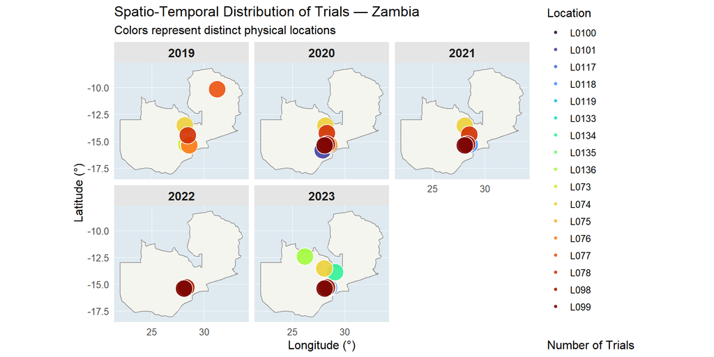

Figure 1

```r
coords <- data %>%
  transmute(loc, env, YEAR,
            LAT_raw = as.numeric(LAT),
            LON_raw = as.numeric(LON),
            LAT = ifelse(abs(LAT_raw) > 90, LAT_raw / 1000, LAT_raw),
            LON = ifelse(abs(LON_raw) > 180, LON_raw / 1000, LON_raw)) %>%
  filter(!is.na(LAT), !is.na(LON))

loc_year <- coords %>%
  group_by(loc, YEAR) %>%
  summarise(n_trials = n_distinct(env),
            LAT = mean(LAT), LON = mean(LON),
            .groups = "drop")

zambia_border <- map_data("world", region = "Zambia")

p_map_year <- ggplot() +
  geom_polygon(data = zambia_border,
               aes(x = long, y = lat, group = group),
               fill = "#f5f5f0", colour = "grey60", linewidth = 0.4) +
  geom_point(data = loc_year,
             aes(x = LON, y = LAT, size = n_trials, fill = loc),
             shape = 21, colour = "white", stroke = 0.6, alpha = 0.9) +
  scale_size_area(name = "Number of Trials", max_size = 8, breaks = c(1, 2, 3)) +
  scale_fill_viridis_d(option = "turbo", name = "Location") +
  coord_quickmap() +
  facet_wrap(~ YEAR) +
  labs(x = "Longitude (°)", y = "Latitude (°)",
       title = "Spatio-Temporal Distribution of Trials — Zambia",
       subtitle = "Colors represent distinct physical locations") +
  theme_minimal(base_size = 12) +
  theme(panel.background = element_rect(fill = "#dfe9f0", colour = NA),
        panel.grid.major = element_line(colour = "white", linewidth = 0.3),
        strip.background = element_rect(fill = "grey90", colour = NA),
        strip.text = element_text(face = "bold", size = 12),
        legend.position = "right")

print(p_map_year)
```

```r
env_year_table <- data |>
  distinct(loc, YEAR, env) |>
  pivot_wider(
    names_from = YEAR,
    values_from = env,
    values_fn = list(env = paste),
    values_fill = "-"
  )

env_year_table |>
  gt(rowname_col = "loc") |>
  tab_header(
    title = "Environment distribution"
  ) |>
  cols_align(
    align = "center",
    columns = everything()
  ) |>
  tab_style(
    style = cell_text(weight = "bold"),
    locations = cells_column_labels()
  ) |>
  tab_style(
    style = cell_text(weight = "bold"),
    locations = cells_stub()
  ) |>
  tab_options(
    table.width = pct(100),
    table.font.size = 12
  )
```

Table 1: Environments combination (local x year)

Environment distribution

|  | 2019 | 2020 | 2021 | 2022 | 2023 |
| --- | --- | --- | --- | --- | --- |
| L073 | E0103 | E0170 | - | E0253 | - |
| L074 | E0104 | E0172 | E0227 | E0255 | E0282 |
| L075 | E0105 | E0174 | - | - | - |
| L076 | E0106 | - | - | - | - |
| L077 | E0107 | - | - | - | - |
| L078 | E0108 | E0175 | E0230 | - | - |
| L098 | - | E0169 | E0225 | E0252 | E0280 |
| L099 | - | E0171 | E0226 | E0254 | E0281 |
| L0100 | - | E0173 | - | - | - |
| L0101 | - | E0176 | - | - | - |
| L0117 | - | - | E0224 | - | - |
| L0118 | - | - | E0228 | - | E0283 |
| L0119 | - | - | E0229 | - | - |
| L0133 | - | - | - | - | E0278 |
| L0134 | - | - | - | - | E0279 |
| L0135 | - | - | - | - | E0284 |
| L0136 | - | - | - | - | E0285 |

# Methodology

## Exploratory Data Analysis

First, we performed some exploratory data analysis ([details](https://htmlpreview.github.io/?https://github.com/morenobm/statistical-genetics-I/blob/main/Final%20project/Multi%20Trial%20EDA.html))

In this step, potential outliers were identified as values more than three standard deviations from the mean Figure 2 . These values were analysed to verify if they were agronomically consistent before removing them.

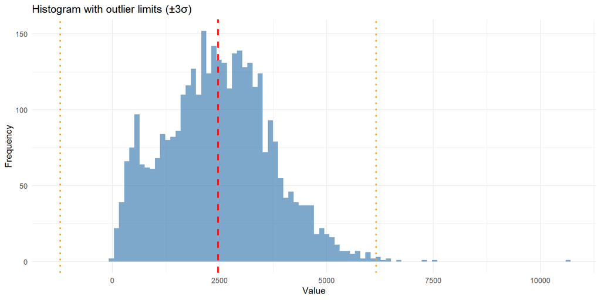

Figure 2

```r
# Normal Distribution Sd's
ggplot(data, aes(x = GY)) +
  geom_histogram(bins = 100, fill = "steelblue", alpha = 0.7) +
  geom_vline(xintercept = mean(data$GY, na.rm = TRUE),
             color = "red", linetype = "dashed", size = 1) +
  geom_vline(xintercept = mean(data$GY, na.rm = TRUE) +
               c(-3, 3) * sd(data$GY, na.rm = TRUE),
             color = "orange", linetype = "dotted", size = 1) +
  labs(title = "Histogram with outlier limits (±3σ)",
       x = "Value", y = "Frequency") +
  theme_minimal()

# # Boxplot outliers
# p_hist <- ggplot(data, aes(x = GY)) +
#   geom_histogram(bins = 100, fill = "steelblue", alpha = 0.7) +
#   theme_minimal() +
#   theme(axis.title.x = element_blank())
#
# p_box <- ggplot(data, aes(y = GY, x = "")) +
#   geom_boxplot(fill = "steelblue", alpha = 0.7, outlier.color = "red",
#                outlier.size = 2, outlier.alpha = 0.5) +
#   coord_flip() +
#   theme_minimal() +
#   theme(axis.title.y = element_blank(),# p_hist / p_box + plot_layout(heights = c(3, 1))

#         axis.text.y = element_blank())
#
# p_hist / p_box + plot_layout(heights = c(3, 1))

## Removing outliers
df <- data|>
  mutate (GY = case_when(
    GY == 10650.85 ~ NA,
    TRUE ~ GY
  )) |>
  mutate(PH_R8 = case_when(
    PH_R8 == 0 ~ NA,
    PH_R8 == 0.0 ~ NA,
    PH_R8 == 308.33 ~ NA,
    TRUE ~ PH_R8
  ))

## Converting columns
df$YEAR <- as.factor(df$YEAR)
df$loc <- as.factor(df$loc)
df$env <- as.factor(df$env)
df$check <- as.factor(df$check)
df$rep <- as.factor(df$rep)
df$gen <- as.factor(df$gen)
df$RAINFED <- as.factor(df$RAINFED)
```

## Single-Trial

After that, each trial was analysed separately, to have a better understanding of the aspects related to the quality of the data collected in each trial. This was done by analysing the broad-sense heritability ($H^{2}$) and the significance of the genetic variance by LRT test ([details](https://htmlpreview.github.io/?https://github.com/morenobm/statistical-genetics-I/blob/main/Final%20project/data_analysis_RCBD.html#summary-of-grain-yield-model-analysis))

Within each trial (RCBD) there are 3 blocks and approximately 30 genotypes, and the statistical model used is describe as follows:

$$y_{ij}=\mu +b_{j}+g_{i}+e_{ij}$$

Where:

$b_{j}$ is the block fixed effects

$g_{i}$ is the genotype’s random effects, where $g_i \sim N(0, \sigma^2_g)$. This was decided due to the unbalanced nature of the data, as some trials had missing plots.

$e_{ij}$ is the residual random effect, where $e_{ij} \sim N(0, \sigma^2_e)$. That is, assuming independence of residuals within trials

The broad-sense heritability was estimated in three different ways, being the last, more appropriate for unbalanced scenarios:

- Individual/plot level: $H² = \frac{\sigma²_g}{ \sigma²_g + \sigma²_e}$
- Genotype level: $H² = \frac{\sigma²_g}{ \sigma²_g + \frac{\sigma^2_e}{3}}$
- Cullis, 2006: $H^2 = 1 - \frac{\bar{SED^2}}{2\sigma²_g}$

```r
# Lista de ambientes
envs_list <- unique(as.character(df$env))

# Verificando dados faltantes para GY em cada ENV
info_env_GH <- df |>
  group_by(env) |>
  summarise(
    obs = n(),
    NAs = sum(is.na(GY)),
    .groups = "drop")

# Rodando para cada trial isoladamente
singleTrial_models_GY <- list()
singleTrial_varcomp_GY <- list()
singleTrial_blup_GY <- list()
singleTrial_reliability_GY <- list()
tabela_geral_GY <- data.frame(env = character(),LRTstat = numeric(),pvalue = numeric(),significance = logical(), h2_plot = numeric(),h2_gen = numeric(), h2_cullis = numeric(), cv = numeric(), stringsAsFactors = FALSE)

for (i in envs_list){

  df_env <- df |> filter(env == i)
  df_env$gen <- as.factor(df_env$gen)
  df_env$rep <- as.factor(df_env$rep)
  i <- as.character(i)

  model <- asreml(fixed = GY ~ rep,
                               random = ~ gen ,
                               data = df_env,
                               maxit = 100,
                               na.action = na.method(y=c("omit")))

  varcomp <- summary(model)$varcomp

  blups <- predict.asreml(model, classify = "gen", sed = TRUE)

  pred_BLUP <- blups$pvals |>
    dplyr::select(predicted.value, dplyr::everything()) |>
    dplyr::arrange(desc(predicted.value))

  m_red_GY <- asreml(fixed = GY ~ rep,
                               data = df_env,
                               maxit = 100,
                               na.action = na.method(y=c("omit")))

  pval <- lrt(model, m_red_GY, boundary = T)

  h2_plot <- vpredict(model, H2 ~ V1/(V1+V2)) # nível de parcela
  h2_gen <- varcomp[1,1] / (varcomp[1,1]+(varcomp[2,1]/3)) # ind
  h2_cullis <- 1-(mean(blups$sed[upper.tri(blups$sed)]^2)/(2*varcomp[1,1]))

  cv <- sqrt(varcomp[2,1])/mean(df_env$GY, na.rm=T)

  reliability <- 1 - (pred_BLUP$std.error^2/varcomp[1,1])

  tabela_geral_GY <- rbind(tabela_geral_GY,
    data.frame(
      env = i,
      LRTstat = round(pval$`LR-statistic`,digits=3),
      pvalue = round(pval$`Pr(Chisq)`,digits=4) ,
      significance = pval$`Pr(Chisq)` < 0.05,
      h2_plot = round(h2_plot$Estimate,digits=4),
      h2_gen = round(h2_gen,digits = 4),
      h2_cullis = round(h2_cullis,digits = 4),
      cv = round((cv*100),digits=2)))

  singleTrial_models_GY[[i]] <- model
  singleTrial_varcomp_GY[[i]] <- varcomp
  singleTrial_blup_GY[[i]] <- blups$pvals
  singleTrial_reliability_GY[[i]] <- reliability
  }
```

```r
# Removing envs "E0108", "E0175","E0224", "E0280", "E0281", "E0285"
df_filter <- df |> filter(!(env %in% c("E0108", "E0175","E0224", "E0280", "E0281", "E0285")))

# New table
env_year_table <- df_filter |>
  distinct(loc, YEAR, env) |>
  pivot_wider(
    names_from = YEAR,
    values_from = env,
    values_fn = list(env = paste),
    values_fill = "-"
  )
env_year_table |>
  gt(rowname_col = "loc") |>
  tab_header(
    title = "Environment distribution"
  ) |>
  cols_align(
    align = "center",
    columns = everything()
  ) |>
  tab_style(
    style = cell_text(weight = "bold"),
    locations = cells_column_labels()
  ) |>
  tab_style(
    style = cell_text(weight = "bold"),
    locations = cells_stub()
  ) |>
  tab_options(
    table.width = pct(100),
    table.font.size = 12
  )
```

Environment distribution

|  | 2019 | 2020 | 2021 | 2022 | 2023 |
| --- | --- | --- | --- | --- | --- |
| L073 | E0103 | E0170 | - | E0253 | - |
| L074 | E0104 | E0172 | E0227 | E0255 | E0282 |
| L075 | E0105 | E0174 | - | - | - |
| L076 | E0106 | - | - | - | - |
| L077 | E0107 | - | - | - | - |
| L098 | - | E0169 | E0225 | E0252 | - |
| L099 | - | E0171 | E0226 | E0254 | - |
| L0100 | - | E0173 | - | - | - |
| L0101 | - | E0176 | - | - | - |
| L0118 | - | - | E0228 | - | E0283 |
| L0119 | - | - | E0229 | - | - |
| L078 | - | - | E0230 | - | - |
| L0133 | - | - | - | - | E0278 |
| L0134 | - | - | - | - | E0279 |
| L0135 | - | - | - | - | E0284 |

## Multi-trial

To analyze genotypes performance in different environments, the following mixed model was used. The initial version of the model is:

$$\mathbf{y}= \mathbf{1}\mu + \mathbf{Z}_1\mathbf{e} + \mathbf{Z}_2\mathbf{b} + \mathbf{Z}_3\mathbf{g} + \varepsilon$$

Where:

$\mathbf{e}$ is the environment random effects, as the environments (local x year combinations) can be treated as a random sample of all possible combinations of these factors

$\mathbf{b}$ is the block random effects, as they are nested in environments, with $\mathbf{b} \sim N(0,\sigma^2_b\mathbf{B})$

$\mathbf{g}$ is the genotype’s random effects, with $\mathbf{g} \sim N(0,\sigma^2_g\mathbf{G})$

$\mathbf{\varepsilon}$ is the residual random effect, with $\mathbf{\varepsilon} \sim N(0,\sigma^2_e\mathbf{R})$

Different covariances structures were tested for the random effects in these models. Each one of the models make different assumptions regarding the residuals, block or genetic random distribution. First, the residuals covariance matrix was analysed, then blocks and finally the covariance matrix of genetic effects.

- **Model 1**
  - G: compound symmetry (genetic variance is homogeneous for genotypes in different environments and the covariance between same genotypes in any two environments is constant)
  - R: identity (all residuals have the same variance in different environments)
  - B: identity (blocks in different environment have the same variance)

```r
# Model 1
mod1 <- asreml(
  fixed    = GY ~ 1,
  random   = ~ env + env:rep + gen + gen:env,
  residual = ~ idv(units),
  data     = df_filter,
  maxit = 100)
```

```
ASReml Version 4.2 26/06/2026 21:18:05
          LogLik        Sigma2     DF     wall
  1     -23230.34           1.0   2960   21:18:05
  2     -22463.28           1.0   2960   21:18:05
  3     -21673.42           1.0   2960   21:18:05
  4     -21209.03           1.0   2960   21:18:05
  5     -21037.46           1.0   2960   21:18:05
  6     -21019.21           1.0   2960   21:18:05
  7     -21018.71           1.0   2960   21:18:05
  8     -21018.70           1.0   2960   21:18:05
```

- **Model 2**
  - G: compound symmetry (genetic variance is homogeneous for genotypes in different environments and the covariance between same genotypes in any two environments is constant)
  - R: block-diagonal (each environment has its own residual variance)
  - B: identity (blocks in different environment have the same variance)

The assumption regarding R seems to be more reasonable, as different environments impacts differently on the residuals.

```r
# Model 2
mod2 <- asreml(
  fixed    = GY ~ 1,
  random   = ~ env + env:rep + gen + gen:env,
  residual = ~ dsum(~idv(units) | env),
  data     = df_filter,
  maxit = 100)
```

```
ASReml Version 4.2 26/06/2026 21:18:05
          LogLik        Sigma2     DF     wall
  1     -28119.99           1.0   2960   21:18:05
  2     -25933.89           1.0   2960   21:18:05
  3     -23544.65           1.0   2960   21:18:05
  4     -21902.20           1.0   2960   21:18:05
  5     -21022.47           1.0   2960   21:18:05
  6     -20756.01           1.0   2960   21:18:05
  7     -20704.34           1.0   2960   21:18:05
  8     -20700.17           1.0   2960   21:18:05
  9     -20700.00           1.0   2960   21:18:05
 10     -20699.98           1.0   2960   21:18:05
 11     -20699.97           1.0   2960   21:18:05
 12     -20699.97           1.0   2960   21:18:05
```

As in this dataset there were no information about the position of plots in the field, we were not capable of doing classical spatial corrections, so these were the only structures considered in the covariance matrix R.

Now, block covariance matrix was analysed:

- **Model 3**
  - G:compound symmetry (genetic variance is homogeneous for genotypes in different environments and the covariance between same genotypes in any two environments is constant)
  - R: block-diagonal (each environment has its own residual variance)
  - B: block-diagonal (each environment has its own block variance)

```r
# Model 3
mod3 <- asreml(
  fixed    = GY ~ 1,
  random   = ~ env + at(env):rep + gen + gen:env,
  residual = ~ dsum(~idv(units) | env),
  data     = df_filter,
  maxit = 100)
```

```
ASReml Version 4.2 26/06/2026 21:18:05
          LogLik        Sigma2     DF     wall
  1     -28119.99           1.0   2960   21:18:06  ( 17 restrained)
  2     -25924.56           1.0   2960   21:18:06  (  3 restrained)
  3     -23529.85           1.0   2960   21:18:06  (  2 restrained)
  4     -21884.82           1.0   2960   21:18:06  (  4 restrained)
  5     -21131.74           1.0   2960   21:18:06  (  5 restrained)
  6     -20821.32           1.0   2960   21:18:06  (  6 restrained)
  7     -20715.32           1.0   2960   21:18:06  (  5 restrained)
  8     -20688.41           1.0   2960   21:18:06  (  3 restrained)
  9     -20683.79           1.0   2960   21:18:06  (  3 restrained)
 10     -20683.21           1.0   2960   21:18:06  (  2 restrained)
 11     -20683.12           1.0   2960   21:18:06  (  1 restrained)
 12     -20683.11           1.0   2960   21:18:06  (  1 restrained)
 13     -20683.11           1.0   2960   21:18:06
```

Now, the genetic part was analysed.

- **Model 4**
  - G: block-diagonal (each environment has its own genetic variance, but the genetic effect from different environments are not correlated)
  - R: block-diagonal (each environment has its own residual variance)
  - B: identity (all blocks have the same variance)

In this model, the genotype effect is nested within the diagonal structure of environments. That means that each environment has its own genetic variance, which seems reasonable, but, this structure assumes that observations from the same genotype in different environments are not correlated, which is a strong assumption.

```r
# Model 4
mod4 <- asreml(
  fixed    = GY ~ 1,
  random   = ~ env + env:rep + diag(env):gen,
  residual = ~ dsum(~idv(units) | env),
  data     = df_filter,
  maxit = 100)
```

```
ASReml Version 4.2 26/06/2026 21:18:06
          LogLik        Sigma2     DF     wall
  1     -29538.30           1.0   2960   21:18:06
  2     -26908.64           1.0   2960   21:18:06
  3     -24023.32           1.0   2960   21:18:06
  4     -22025.82           1.0   2960   21:18:06
  5     -20950.99           1.0   2960   21:18:06
  6     -20633.56           1.0   2960   21:18:06
  7     -20576.41           1.0   2960   21:18:06
  8     -20572.26           1.0   2960   21:18:06
  9     -20572.21           1.0   2960   21:18:06
 10     -20572.21           1.0   2960   21:18:06
```

- **Model 5**
  - G: Heterogeneous compound symmetry (each environment has its own genetic variance, and there is a uniform correlation that connects genotypes in different environments)
  - R: block-diagonal (each environment has its own residual variance)
  - B: identity (all blocks have the same variance)

In this model, the genotype effect is also nested within environments, which has heterogeneous variances for different environments and uniform correlation between environments. So, genotypes from the same environment have the same genetic variance, and the same genotypes in different environments are connected by a uniform correlation. This also allow the prediction of genotypes at untested environments.

```r
# Model 5
mod5 <- asreml(
  fixed    = GY ~ 1,
  random   = ~ env + env:rep + corh(env):gen,
  residual = ~ dsum(~idv(units) | env),
  data     = df_filter,
  maxit = 100)
```

```
ASReml Version 4.2 26/06/2026 21:18:06
          LogLik        Sigma2     DF     wall
  1     -29333.53           1.0   2960   21:18:06
  2     -26748.67           1.0   2960   21:18:06
  3     -23913.35           1.0   2960   21:18:07
  4     -21951.39           1.0   2960   21:18:07
  5     -20894.94           1.0   2960   21:18:07
  6     -20579.27           1.0   2960   21:18:07
  7     -20519.89           1.0   2960   21:18:07
  8     -20515.01           1.0   2960   21:18:07
  9     -20514.88           1.0   2960   21:18:07
 10     -20514.80           1.0   2960   21:18:07
 11     -20514.78           1.0   2960   21:18:07
 12     -20514.78           1.0   2960   21:18:07
 13     -20514.78           1.0   2960   21:18:07
```

- **Model 6 and 7**
  - G: Unstructured with heterogeneous variances (each environment has its own genetic variance, and different correlations connect genotypes of different environments)
  - R: block-diagonal (each environment has its own residual variance)
  - B: identity (all blocks have the same variance)

In both models above, the genotype effect is also nested within environments, which has heterogeneous variances for different environments and a distinct correlation for each pair of environments. So, genotypes from the same environment have the same variance, and observations from the same genotype in different environments are connected by a correlation that is specific to that pair of environments. That is different from Model 5, where a single correlation value was applied to every pair of environment.

Although the assumptions of these models are less stronger, the variance component estimation did not converge, probably because of the high number of parameters. So we were not able to use **Model 6 and 7**.

```r
# Model 6 and 7
mod6 <- asreml(
  fixed    = GY ~ 1,
  random   = ~ env + env:rep + us(env):gen,
  residual = ~ dsum(~idv(units) | env),
  data     = df_filter,
  maxit = 300)

mod7 <- asreml(
  fixed    = GY ~ 1,
  random   = ~ env + env:rep + corgh(env):gen,
  residual = ~ dsum(~idv(units) | env),
  data     = df_filter,
  maxit = 300)
```

After model adjustment, the best model was chosen based on AIC, then, the predicted values (based on BLUPs) were obtained for genotype-environment combinations.

Finally, genotypes’ stabilities were analysed through different indeces:

- Eberhart & Russel (1966): $Y_{ij} = \mu_{i} + \beta_{1}I_j + \delta_{ij}$
- AMMI: $Y_{ij}=μ+g_i+e_j+(ge)_{ij}$
- Safety-First (Eskridge, 1990): $SF_i = \hat{g_i} - Z_{1-\alpha} \sqrt{V_i}$
- Pi-Index (Lin & Binns, 1988): $P_i = \frac{\sum_{j=1}^{p} \left[ \hat{g}_{ij} - \max(\hat{g}_{j}) \right]^2}{2 \times p}$

The first two indeces are classical methods based on regression/ANOVA methods, so, they are not the best approaches to deal with unbalanced data. They were used to analyse if they would provide a general concordance with the last two indeces. Safety-First and Pi-Index, were used to make a decision regarding the cultivar selection, as they are based on our BLUP predictions.

# Results/Discussion

## Single-Trial

```r
tabela_geral_GY |>
  mutate(
    highlight = env %in% c("E0108", "E0175","E0224", "E0280", "E0281", "E0285")) |>
  gt(rowname_col = "env") |>
  tab_header(
    title = "Single-trial analysis for grain yield"
  ) |>
  tab_style(
    style = cell_fill(color = "#e8f5e9"),
    locations = cells_body(
      rows = highlight == TRUE
    )
  ) |>
  cols_hide(
    columns = c(significance, highlight)
  ) |>
  cols_label(
    LRTstat = "LRT",
    pvalue = "P-value",
    h2_plot = html("H<sup>2</sup><sub>plot</sub>"),
    h2_gen = html("H<sup>2</sup><sub>genotype</sub>"),
    h2_cullis = html("H<sup>2</sup><sub>Cullis</sub>"),
    cv = "CV (%)"
  ) |>
  fmt_number(
    columns = c(LRTstat, pvalue, h2_plot, h2_gen, h2_cullis, cv),
    decimals = 4
  ) |>
  cols_align(
    align = "center",
    columns = everything()
  ) |>
  tab_options(
    table.font.size = px(12),
    table.width = pct(100)
  )
```

Table 2

Single-trial analysis for grain yield

|  | LRT | P-value | H<sup>2</sup><sub>plot</sub> | H<sup>2</sup><sub>genotype</sub> | H<sup>2</sup><sub>Cullis</sub> | CV (%) |
| --- | --- | --- | --- | --- | --- | --- |
| E0103 | 7.8640 | 0.0025 | 0.2728 | 0.5295 | 0.5295 | 21.5300 |
| E0104 | 56.8520 | 0.0000 | 0.6869 | 0.8681 | 0.8681 | 12.0100 |
| E0105 | 5.4070 | 0.0100 | 0.2352 | 0.4799 | 0.4775 | 32.3900 |
| E0106 | 14.4480 | 0.0001 | 0.3701 | 0.6381 | 0.6381 | 19.3800 |
| E0107 | 10.3730 | 0.0006 | 0.3201 | 0.5855 | 0.5831 | 42.0400 |
| E0108 | 0.0000 | 0.5000 | 0.0000 | 0.0000 | 0.0000 | 44.7200 |
| E0169 | 11.4330 | 0.0004 | 0.3294 | 0.5958 | 0.5959 | 18.4300 |
| E0170 | 7.7510 | 0.0027 | 0.2710 | 0.5272 | 0.5246 | 29.0300 |
| E0171 | 17.0960 | 0.0000 | 0.4122 | 0.6778 | 0.6754 | 15.6100 |
| E0172 | 15.6690 | 0.0000 | 0.3873 | 0.6547 | 0.6523 | 14.5800 |
| E0173 | 34.3530 | 0.0000 | 0.5573 | 0.7906 | 0.7907 | 14.3400 |
| E0174 | 2.6920 | 0.0504 | 0.1586 | 0.3612 | 0.3589 | 25.4800 |
| E0175 | 0.0000 | 0.5000 | 0.0000 | 0.0000 | 0.0000 | 31.8800 |
| E0176 | 12.6010 | 0.0002 | 0.3473 | 0.6149 | 0.6123 | 17.8900 |
| E0224 | 1.3450 | 0.1231 | 0.1105 | 0.2714 | 0.2714 | 18.3200 |
| E0225 | 4.8030 | 0.0142 | 0.2191 | 0.4571 | 0.4496 | 40.6200 |
| E0226 | 17.9010 | 0.0000 | 0.4111 | 0.6768 | 0.6768 | 22.7900 |
| E0227 | 189.4440 | 0.0000 | 0.9499 | 0.9827 | 0.9825 | 19.0800 |
| E0228 | 34.2640 | 0.0000 | 0.5567 | 0.7902 | 0.7902 | 17.3300 |
| E0229 | 110.9310 | 0.0000 | 0.8549 | 0.9465 | 0.9458 | 18.9500 |
| E0230 | 56.7910 | 0.0000 | 0.6866 | 0.8679 | 0.8680 | 34.7300 |
| E0252 | 29.7910 | 0.0000 | 0.5723 | 0.8006 | 0.7820 | 42.7400 |
| E0253 | 31.7430 | 0.0000 | 0.6523 | 0.8491 | 0.8243 | 40.7800 |
| E0254 | 51.0900 | 0.0000 | 0.7365 | 0.8934 | 0.8934 | 13.3500 |
| E0255 | 58.0120 | 0.0000 | 0.7691 | 0.9090 | 0.9090 | 15.1200 |
| E0278 | 12.0030 | 0.0003 | 0.3701 | 0.6380 | 0.6428 | 21.0700 |
| E0279 | 10.6290 | 0.0006 | 0.3782 | 0.6459 | 0.6426 | 17.4600 |
| E0280 | 1.3410 | 0.1234 | 0.1336 | 0.3163 | 0.3191 | 21.6600 |
| E0281 | 2.0840 | 0.0744 | 0.1410 | 0.3299 | 0.3310 | 20.9700 |
| E0282 | 19.1730 | 0.0000 | 0.4870 | 0.7401 | 0.7409 | 19.1000 |
| E0283 | 22.6990 | 0.0000 | 0.5052 | 0.7539 | 0.7575 | 22.4300 |
| E0284 | 58.5330 | 0.0000 | 0.7312 | 0.8908 | 0.8926 | 11.1100 |
| E0285 | 0.0100 | 0.4597 | 0.0106 | 0.0312 | 0.0321 | 34.1300 |

Based on the LRT and on the heritabilites shown above, the genetic variance within environments “E0108”, “E0175”, “E0224”, “E0280”, “E0281”, “E0285” was not significant, meaning that observations from this trial have a great portion of noise. Because of this, these trials were removed from the multi-environment analysis.

By our single-trial analysis, it was clear that occurred fluctuations in the top-ranking positions in each environment, as it can be seen in Figure 3 . This aspect highlights the presence of a strong Genotype by Environment (GxE) interaction (cross-over patterns). Due to this interaction pattern, we will proceed to a multi-environment analysis, aiming to assess genotypes with higher stability for the environments considered.

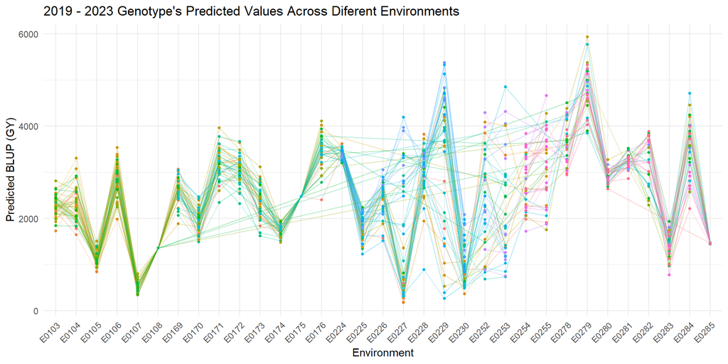

Figure 3

```r
blup_all_GY <- bind_rows(
  lapply(names(singleTrial_blup_GY), function(env){
    df <- singleTrial_blup_GY[[env]]
    df$env <- env
    return(df)}))

ggplot(blup_all_GY,
       aes(x = env, y = predicted.value, group = gen, color = gen)) +
      geom_line(alpha = 0.3) +
      geom_point(size = 1) +
      theme_minimal() +
      labs(x = "Environment", y = "Predicted BLUP (GY)",
        title = "2019 - 2023 Genotype's Predicted Values Across Diferent Environments") +
      theme(axis.text.x = element_text(angle = 45, hjust = 1),legend.position = "none")
```

## Multi-Trial

In this step, only the 27 filtered environments were considered. By analyzing the AIC values in Figure 4, `Model 5` presented the smaller one, being the model selected for all downstream analysis (BLUP predictions, stability indeces…)

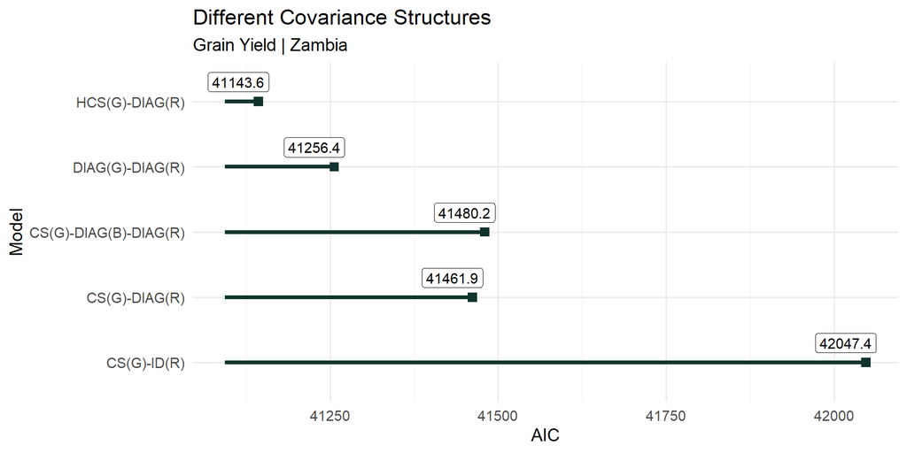

Figure 4: AIC values for different models

```r
aic1 <- summary(mod1)$aic
aic2 <- summary(mod2)$aic
aic3 <- summary(mod3)$aic
aic4 <- summary(mod4)$aic
aic5 <- summary(mod5)$aic

modelos_aic <- data.frame(
  modelo = factor(
    c("CS(G)-ID(R)", "CS(G)-DIAG(R)", "CS(G)-DIAG(B)-DIAG(R)", "DIAG(G)-DIAG(R)",
      "HCS(G)-DIAG(R)"),
    levels = c("CS(G)-ID(R)", "CS(G)-DIAG(R)", "CS(G)-DIAG(B)-DIAG(R)", "DIAG(G)-DIAG(R)",
               "HCS(G)-DIAG(R)")
  ), AIC = c(aic1, aic2, aic3, aic4, aic5))

  ggplot(modelos_aic, aes(y = modelo, x = AIC)) +
    geom_point(size = 3, shape = 15, colour = "#10342d") +
    geom_segment(aes(x = min(AIC) - 50, xend = AIC, y = modelo, yend = modelo),
                 linewidth = 1.5, colour = "#10342d") +
    geom_label(aes(label = round(AIC, 1)), size = 4,
               position = position_nudge(y = 0.3, x = -30)) +
    theme_minimal(base_size = 14) +
    labs(y = "Model", x = "AIC",
         title = "Different Covariance Structures",
         subtitle = "Grain Yield | Zambia")
```

```
ASReml Version 4.2 26/06/2026 21:18:09
          LogLik        Sigma2     DF     wall
  1     -20514.78           1.0   2960   21:18:09
  2     -20514.78           1.0   2960   21:18:09
 3     -20514.78           1.0   2960   21:18:09
```

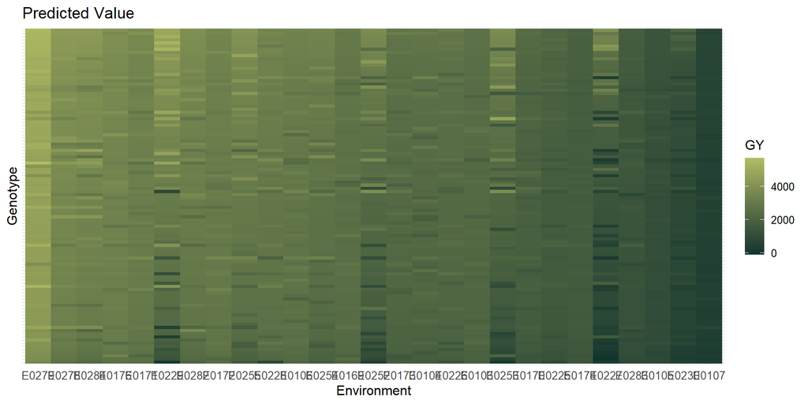

Figure 5: Predicted Values in Different Environments

```r
  pred <- predict.asreml(object = mod5,classify = "gen:env")$pvals

  pred |>
    ggplot(aes(x = reorder(env, -predicted.value),
               y = reorder(gen, predicted.value),
               fill = predicted.value)) +
    geom_tile() +
    theme_minimal(base_size = 12) +
    theme(legend.position = "right",
          axis.text.y = element_blank(),
          axis.text.x = element_text(size = 10),
          axis.ticks.y = element_blank()) +
    scale_fill_gradient(low = "#10342d", high = "#b2bc63") +
    labs(x = "Environment", y = "Genotype", fill = "GY",
         title = "Predicted Value")
```

The heatmap of predicted values from the model for each genotype × environment combination visually synthesizes the three components of phenotypic variation within the network (Figure 5). The horizontal gradient, ranging from light green (E0279, on the left) to dark green (E0107, on the right), reflects the dominant environmental effect, confirming that the mean yield of the environments constitutes the primary source of variation in the network. The vertical gradient, although less intense, represents the genotypic main effect, with genotypes possessing a higher overall mean yield concentrated at the top with consistently lighter shades.

The G×E interaction manifests itself in the patterns that disrupt the monotony of these gradients. Dark cells within predominantly light columns indicate genotypes underperforming in favorable environments. This pattern is particularly evident in E0229, whose profile of intense rank reorganization had already been identified in the AMMI analysis (Figure 7). Conversely, lighter cells within dark columns, visible in E0253, E0225, and E0227, show genotypes with specific adaptability to unfavorable environments. These materials are interesting for targeted recommendations in marginal rainfed regions, a behavior consistent with the specific affinity for E0227 previously identified in the AMMI2 biplot.

### Classical Analysis

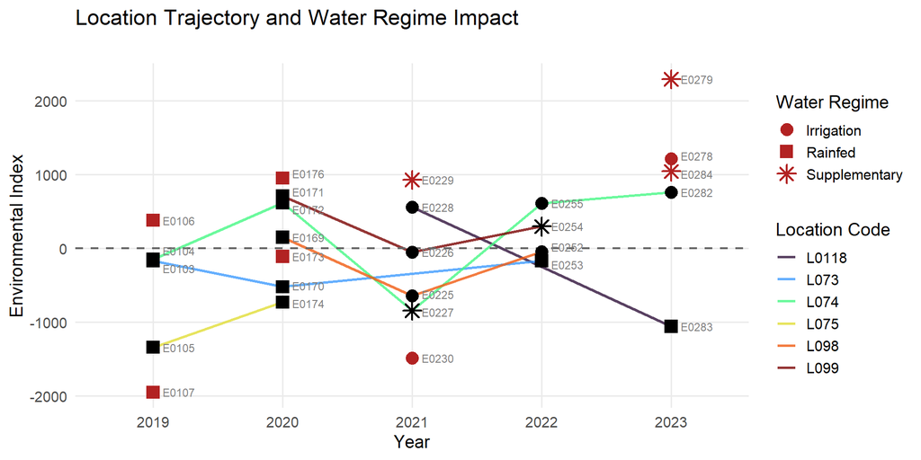

Figure 6: Environmental Index trajectory of the evaluated locations across years

```r
trajectory_index <- df_filter %>%
  group_by(env, loc, YEAR, RAINFED) %>%
  summarise(GY_mean = mean(GY, na.rm = TRUE), .groups = "drop") %>%
  mutate(index = GY_mean - mean(df_filter$GY, na.rm = TRUE)) %>%
  group_by(loc) %>%
  mutate(total_years = n_distinct(YEAR)) %>%
  ungroup()

ggplot(trajectory_index, aes(x = factor(YEAR), y = index, group = loc)) +
  geom_line(data = subset(trajectory_index, total_years > 1),
            aes(colour = loc), linewidth = 1, alpha = 0.8) +
  geom_hline(yintercept = 0, linetype = "dashed", linewidth = 0.8, colour = "grey40") +

  geom_point(data = subset(trajectory_index, total_years > 1),
             aes(shape = as.factor(RAINFED)), colour = "black", size = 4, stroke = 1.2) +
  geom_point(data = subset(trajectory_index, total_years == 1),
             aes(shape = as.factor(RAINFED)), colour = "firebrick", size = 4, stroke = 1.2) +

  ggrepel::geom_text_repel(aes(label = env), colour = "grey50", size = 3,
                           nudge_x = 0.2,
                           direction = "y",
                           segment.color = "grey80") +

  scale_colour_viridis_d(option = "turbo", name = "Location Code") +
  scale_shape_manual(values = c(16, 15, 8), name = "Water Regime") +

  labs(x = "Year",
       y = "Environmental Index",
       title = "Location Trajectory and Water Regime Impact",
       subtitle = "") +

  theme_minimal(base_size = 14) +
  theme(legend.position = "right",
        panel.grid.minor = element_blank())
```

Analyzing the impact of water regimes over the years reveals a distinct temporal pattern. In 2019 and 2020, all trials within the network were conducted under rainfed conditions. Remarkably, even without supplementary water, several of these early rainfed environments (such as E0106, E0176, E0171, E0172, and E0169) managed to achieve positive environmental indices. However, a clear shift occurred from 2021 onwards: no rainfed trial managed to reach a positive index. During this later period, positive yield performances became exclusively associated with irrigated or supplementary water regimes.

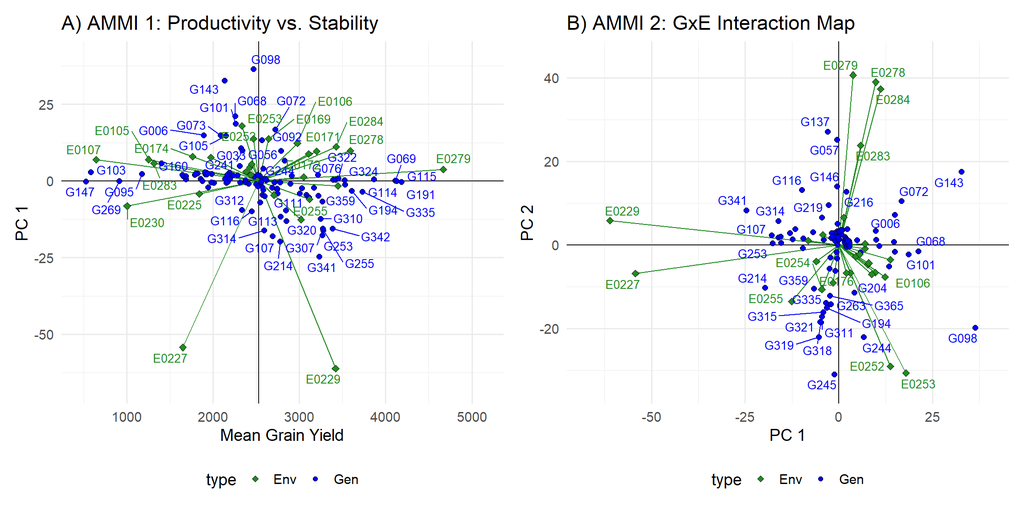

Figure 7: AMMI1 (Mean Yield vs. PC1) and AMMI2 (PC1 vs. PC2) biplots for grain yield across evaluated environments.

```r
df_ammi <- droplevels(df_filter)

media_geral <- mean(df_ammi$GY, na.rm = TRUE)

medias_env <- df_ammi |>
  group_by(env) |>
  summarise(efeito_env = mean(GY, na.rm = TRUE) - media_geral, .groups = "drop")

medias_gen <- df_ammi |>
  group_by(gen) |>
  summarise(efeito_gen = mean(GY, na.rm = TRUE) - media_geral, .groups = "drop")

dat_ammi_completo <- df_ammi |>
  tidyr::complete(env, gen, rep) |>
  left_join(medias_env, by = "env") |>
  left_join(medias_gen, by = "gen") |>
  mutate(
    efeito_gen = ifelse(is.na(efeito_gen), 0, efeito_gen),
    efeito_env = ifelse(is.na(efeito_env), 0, efeito_env),

    GY = ifelse(is.na(GY), media_geral + efeito_env + efeito_gen, GY),

    GY = ifelse(is.na(GY), media_geral, GY)
  ) |>
  select(env, gen, rep, GY)

ammi <- metan::performs_ammi(
  .data = dat_ammi_completo,
  env   = "env",
  gen   = "gen",
  rep   = "rep",
  resp  = "GY",
  verbose = FALSE
)

p_ammi1 <- plot_scores(ammi, type = 1, title = FALSE) +
  labs(title = "A) AMMI 1: Productivity vs. Stability",
       x = "Mean Grain Yield",
       y = "PC 1") +
  theme_minimal(base_size = 14) +
  theme(legend.position = "bottom")

p_ammi2 <- plot_scores(ammi, type = 2, title = FALSE) +
  labs(title = "B) AMMI 2: GxE Interaction Map",
       x = "PC 1",
       y = "PC 2") +
  theme_minimal(base_size = 14) +
  theme(legend.position = "bottom")

p_ammi1 + p_ammi2
```

A strict mathematical of AMMI algorithm is the requirement of a completely balanced two-way classification matrix. Since multi-environment agricultural trials are inherently unbalanced due to localized entries and missing plots, data imputation was performed prior to the analysis. Missing cells were predicted using an additive main effects framework ($Y_{ij} = \mu + G_i + E_j$). This strategy preserved the network’s connectivity and allowed the AMMI model to converge without discarding partially evaluated genotypes or environments, but, this strategy also introduces uncertainty into the analysis.

The multiplicative interaction analysis revealed that the first principal component (PC1) explained 28.1% of the G×E interaction variance, while the second component (PC2) captured 15.7%, accounting for a cumulative total of 43.8% of the interaction sum of squares.In the AMMI1 biplot (Figure 7 A), environment E0279 stood out as the most productive environment in the entire network, exhibiting a high mean yield ceiling combined with moderate interaction scores. Conversely, environments E0227 and E0229 displayed the most extreme scores along the PC1 axis, indicating that these environments exert the strongest forces in altering genotypic rankings relative to the rest of the network. Regarding genotypic performance, G191, G115, and G069 combined high mean grain yields with PC1 scores close to zero, which traditionally suggests a profile of broad adaptability.

However, this pattern must be interpreted with caution. As previously identified in the regression analysis, genotypes such as G191 and G115 were evaluated in only two environments. Because their missing data points were filled using the additive main effects model (which inherently assumes an interaction deviation of zero) their coordinates were artificially dragged toward the biplot origin ($PC1 \approx 0$). Therefore, their apparent stability represents a mathematical artifact of the imputation process on sparse data rather than true biological buffering. In contrast, the group formed by G307, G310, G342, and G335 represents extensively tested materials that consistently achieved grain yields above 2,500 kg/ha with low interaction scores, consolidating them as truly robust candidates for stable performance across the network.

The AMMI2 biplot (Figure 7 B) provided a multidimensional mapping of the interaction, revealing three distinct mega-environments based on the spatial clustering of environmental vectors:(i) High-Potential Managed Network: Environments E0279, E0278, and E0284 grouped tightly in the top-right quadrant, representing favorable conditions under irrigation or supplementary water regimes. Genotypes G137, G057, and G143 displayed strong specific adaptability to this cluster, marking them as ideal candidates for high-investment systems.(ii) High-Yielding Unique Interaction: Environment E0229 isolated itself on the left side of the axis, showcasing a unique interaction profile despite its high mean productivity.(iii) Unfavorable Network: Environments E0227, E0252, and E0253 clustered in the lower quadrants, forming a group of lower-yielding environments with distinct interaction patterns. Genotypes located near the tips of these vectors (such as G245 and G194 towards E0253) express specific affinity for these narrower conditions.

Finally, the central core of the AMMI2 biplot near the origin contains a dense cluster of genotypes, prominently including G307, G310, G342, and G263. Their proximity to the intersection of both interaction axes confirms their stable performance across both multiplicative dimensions, reinforcing their high predictability and broad agronomic buffering across the multi-environment network.

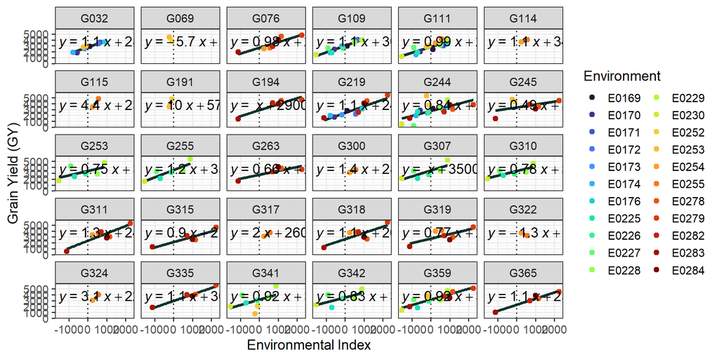

Figure 8: Eberhart and Russell (1966) regression analysis

```r
ERm <- metan::ge_reg(
  .data   = droplevels(df_filter),
  env     = "env",
  gen     = "gen",
  rep     = "rep",
  resp    = "GY",
  verbose = FALSE)

top_gen <- ERm$GY$regression |>
  arrange(desc(b0)) |>
  slice(1:30) |>
  pull(GEN) |>
  as.character()

top_gen <- unique(c(top_gen, "G318"))

ggplot(data = subset(ERm$GY$data, GEN %in% top_gen),
       aes(x = IndAmb, y = Y)) +
  facet_wrap(. ~ GEN) +
  geom_smooth(method = "lm", formula = y ~ x, se = FALSE, colour = "#10342d") +
  geom_point(aes(colour = ENV), size = 2) +
  theme_bw(base_size = 14) +
  geom_vline(xintercept = 0, linetype = "dotted") +
  labs(x = "Environmental Index",
       y = "Grain Yield (GY)",
       colour = "Environment") +
  scale_color_viridis_d(option = "turbo") +
  stat_regline_equation()
```

As illustrated in Figure 8, the Eberhart and Russell regression model was applied to assess the adaptability and phenotypic stability of the top 30 highest-yielding genotypes. While this methodology provides valuable insights into how genotypes respond to environmental variations, a critical examination of the data reveals a significant methodological limitation regarding the number of testing environments.

An important statistical artifact is present among several genotypes that were selected in this top 30 productivity ranking, specifically G114, G115, G191, G300, G317, G322, and G324. These materials were evaluated in only two environments. Mathematically, a linear regression line will always perfectly connect two points. Consequently, there is no dispersion around the line, meaning the deviation from regression ($S^2_{di}$) equals zero by definition. Although this perfect fit might falsely suggest flawless phenotypic stability, it is entirely a mathematical artifact resulting from a lack of degrees of freedom, rather than true biological resilience. Furthermore, this artifact heavily distorts the estimation of their regression parameters, generating unrealistic mean yields ($\beta_0$) and extreme slopes, such as the artificially inflated responsiveness of G191 ($\beta_1 = 10$).

In contrast, evaluating genotypes across a robust multi-environment network captures the genuine biological complexity of G×E interactions. Genotype G244, which is one of the most extensively tested materials in the network, clearly demonstrates this reality. Despite maintaining a competitive mean yield ($\beta_0 = 2700$ kg/ha), its data points are widely scattered around the regression line. This substantial dispersion indicates high unpredictability and a significant interaction with specific environmental factors that are not linearly explained by the environmental index.

Genotypes such as G335, G365, and G310 present a large number of data points that closely follow their respective regression lines, proving that high predictability is biologically attainable when adequately tested.

### Mixed Model Indices

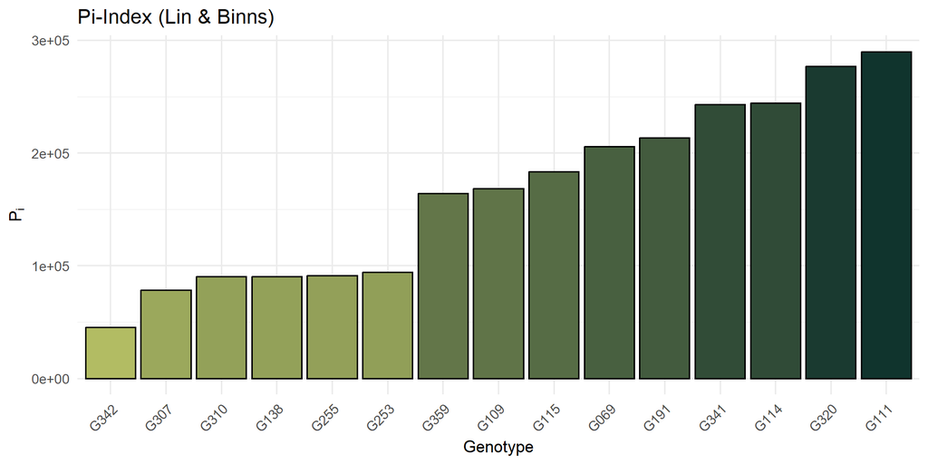

Figure 9: Pi-Index (Top 15 Genotypes) in different environments

```r
  ge_table <- pred[, c("gen", "env", "predicted.value")] |>
    pivot_wider(names_from = "env", values_from = "predicted.value") |>
    column_to_rownames("gen")

  Pi <- apply(ge_table, 1, function(x) {
    sum((x - apply(ge_table, 2, max))^2) / (2 * ncol(ge_table))})

  df_Pi <- data.frame(gen = names(Pi), Pi = Pi) |>
    arrange(Pi) |>
    slice(1:15)

  ggplot(data = df_Pi, aes(x = reorder(gen, Pi), y = Pi)) +
    geom_col(colour = "black", aes(fill = Pi)) +
    scale_fill_gradient(high = "#10342d", low = "#b2bc63") +
    theme_minimal(base_size = 13) +
    theme(axis.text.x = element_text(angle = 45, vjust = 1, hjust = 1),
          legend.position = "none") +
    labs(y = expression(P[i]), x = "Genotype",
         title = "Pi-Index (Lin & Binns)")
```

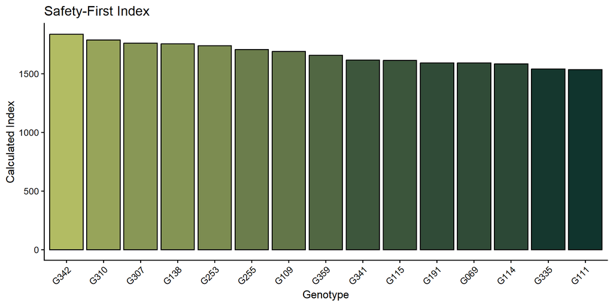

Figure 10: Safety-First Index (Top 15 Genotypes) in different environments

```r
  alpha <- 0.10
  SF <- apply(ge_table, 1, function(x) mean(x) - qnorm(1 - alpha) * sd(x))

  df_SF <- data.frame(gen = names(SF), SF = SF) |>
    arrange(desc(SF)) |>
    slice(1:15)

  ggplot(data = df_SF, aes(x = reorder(gen, -SF), y = SF)) +
    geom_col(colour = "black", aes(fill = SF)) +
    scale_fill_gradient(low = "#10342d", high = "#b2bc63") +
    theme_classic(base_size = 13) +
    theme(axis.text.x = element_text(angle = 45, vjust = 1, hjust = 1),
          legend.position = "none") +
    labs(y = "Calculated Index", x = "Genotype",
         title = "Safety-First Index")
```

The ranking derived from the superiority index ($P_i$) indicates that genotypes with the lowest values exhibit the shortest distance to the maximum performing genotype within each environment, thus identifying materials with superior broad adaptation. Under this criterion, genotypes G342, G307, G310, G138, and G255 stood out with the lowest $P_i$ estimates, demonstrating strong convergence with the results obtained from Eskridge’s safety-first index Figure 9 Figure 10

Interestingly, in the previous single-trial analyses, genotypes G092 and G233 were top-ranked across multiple individual environments, yet they were not selected by the global indices. This discrepancy highlights the importance of accounting for genotype-by-environment ($G \times E$) effects through multi-environment trial (MET) modeling. When evaluated simultaneously across the entire network, the shifting in genotype rankings across locations (crossover interaction) penalizes genotypes with high specific adaptation but low yield stability. This justifies our selection strategy, which prioritizes materials capable of mitigating environmental fluctuations through stable and predictable performance.

Furthermore, the classical stability analyses (AMMI and Eberhart & Russell) also identified genotype G342 as superior. This consensus demonstrates that despite the distinct mathematical foundations, assumptions, and statistical properties of each method, highly stable and high-yielding germplasm can be robustly identified when the genetic signal is strong.

```r
table_connect <- table(as.character(df$env), as.character(df$gen))
table_connect[table_connect > 0] <- 1
table_connect <- as.data.frame(table_connect)

df_water <- df %>%
  distinct(env, RAINFED) %>%
  rename(Var1 = env)

table_connect <- merge(table_connect, df_water, by = "Var1", all.x = TRUE)
table_connect$Status <- ifelse(table_connect$Freq == 0, "Absence", as.character(table_connect$RAINFED))
conect_perc <- tapply(table_connect$Freq, table_connect$Var2, sum) / length(unique(df_filter$env)) * 100

conect_perc <- data.frame(
  Genótipo = names(conect_perc),
  Conectividade = conect_perc
)

conect_perc <- conect_perc[order(conect_perc$Conectividade, decreasing = TRUE), ]

tab_conec <- kable(
  conect_perc,
  caption = "Connectivity of genotypes across experiments",
  align = "c")

table_connect$Var2 <- factor(as.character(table_connect$Var2), levels = conect_perc$Genótipo)
ordem_env <- names(sort(tapply(table_connect$Freq, table_connect$Var1, sum), decreasing = TRUE))
table_connect$Var1 <- factor(as.character(table_connect$Var1), levels = ordem_env)

genotipos_alvo <- c("G342", "G138")
niveis_genotipos <- levels(table_connect$Var2)
rotulos_customizados <- ifelse(niveis_genotipos %in% genotipos_alvo, niveis_genotipos, "")
cores_eixo_x <- ifelse(niveis_genotipos %in% genotipos_alvo, "red", "black")
```

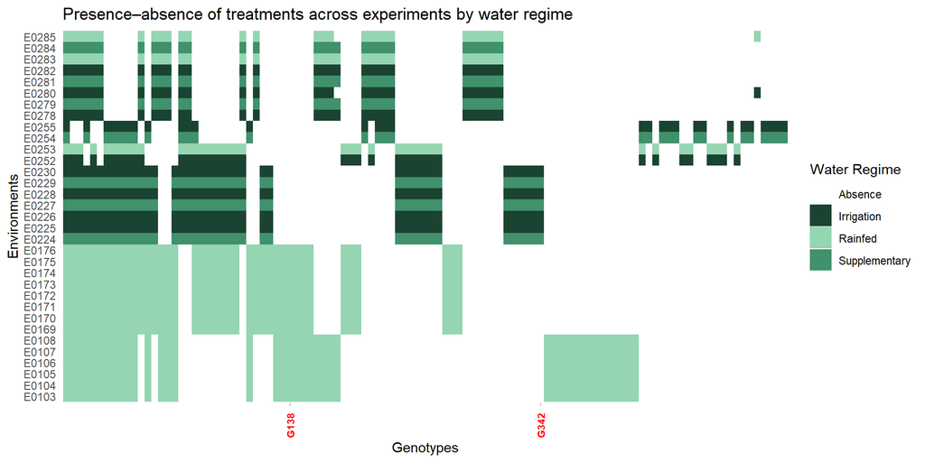

Figure 11: Genotypes Presence on Different Environments

```r
ggplot(table_connect, aes(x = Var2, y = Var1, fill = Status)) +
  geom_tile() +
  scale_fill_manual(
    values = c(
      "Absence"       = "white",
      "Irrigation"    = "#1b4332",
      "Supplementary" = "#40916c",
      "Rainfed"       = "#95d5b2")
  ) +
  scale_x_discrete(labels = rotulos_customizados) +
  labs(
    title = "Presence–absence of treatments across experiments by water regime",
    x = "Genotypes",
    y = "Environments",
    fill = "Water Regime"
  ) +
  theme_minimal() +
  theme(

    axis.text.x = element_text(color = cores_eixo_x, angle = 90, vjust = 0.5, hjust = 1, size = 8, face = "bold"),
    axis.ticks.x = element_line(color = ifelse(rotulos_customizados == "", NA, "gray")),
    panel.grid = element_blank() )
```

```
ASReml Version 4.2 26/06/2026 21:24:15
          LogLik        Sigma2     DF     wall
  1     -20514.78           1.0   2960   21:24:21
  2     -20514.78           1.0   2960   21:24:21
 3     -20514.78           1.0   2960   21:24:22
                     component    std.error  z.ratio bound %ch
env               8.723131e+05 2.473409e+05 3.526764     P 0.0
env:rep           2.044612e+04 5.407046e+03 3.781384     P 0.0
env:gen!env!cor   3.997699e-01 5.415290e-02 7.382244     U 0.1
env:gen!env_E0103 9.706147e+04 4.483815e+04 2.164707     P 0.1
env:gen!env_E0104 1.949314e+05 4.969051e+04 3.922910     P 0.0
env:gen!env_E0105 4.729358e+04 2.307921e+04 2.049185     P 0.0
env:gen!env_E0106 2.049071e+05 7.417953e+04 2.762313     P 0.0
env:gen!env_E0107 2.422503e+04 9.966156e+03 2.430730     P 0.1
env:gen!env_E0169 1.193898e+05 4.922438e+04 2.425421     P 0.2
env:gen!env_E0170 1.387436e+05 5.920569e+04 2.343417     P 0.0
env:gen!env_E0171 1.907117e+05 6.483014e+04 2.941713     P 0.0
env:gen!env_E0172 1.437070e+05 5.022374e+04 2.861335     P 0.0
env:gen!env_E0173 1.524049e+05 4.354538e+04 3.499911     P 0.0
env:gen!env_E0174 4.078189e+04 2.596380e+04 1.570721     P 0.0
env:gen!env_E0176 2.266518e+05 8.424124e+04 2.690509     P 0.1
env:gen!env_E0225 1.668993e+05 8.119512e+04 2.055533     P 0.0
env:gen!env_E0226 2.014625e+05 6.848438e+04 2.941730     P 0.0
env:gen!env_E0227 1.680392e+06 3.642661e+05 4.613088     P 0.0
env:gen!env_E0228 3.295659e+05 9.443934e+04 3.489709     P 0.0
env:gen!env_E0229 2.164559e+06 4.939556e+05 4.382092     P 0.0
env:gen!env_E0230 2.318626e+05 5.898965e+04 3.930565     P 0.0
env:gen!env_E0252 1.480670e+06 4.598713e+05 3.219749     P 0.0
env:gen!env_E0253 1.736473e+06 5.387525e+05 3.223137     P 0.0
env:gen!env_E0254 4.005846e+05 1.152372e+05 3.476175     P 0.0
env:gen!env_E0255 7.552864e+05 2.132719e+05 3.541425     P 0.0
env:gen!env_E0278 4.317675e+05 1.803911e+05 2.393508     P 0.1
env:gen!env_E0279 4.884415e+05 2.174688e+05 2.246030     P 0.4
env:gen!env_E0282 4.464926e+05 1.605315e+05 2.781340     P 0.1
env:gen!env_E0283 1.237527e+05 4.288650e+04 2.885587     P 0.0
env:gen!env_E0284 5.722684e+05 1.661838e+05 3.443587     P 0.0
env_E0103!R       1.000000e+00           NA       NA     F 0.0
env_E0103!units   2.552579e+05 4.067888e+04 6.274949     P 0.0
env_E0104!R       1.000000e+00           NA       NA     F 0.0
env_E0104!units   7.700807e+04 1.230951e+04 6.255981     P 0.0
```

[output cut: 60 more lines]

```
 E0106  : 106   G018   :  26   Median :2510.15   Median : 360.6
 E0169  : 106   G033   :  26   Mean   :2483.25   Mean   : 438.7
 E0170  : 106   G034   :  26   3rd Qu.:3116.42   3rd Qu.: 534.1
 E0171  : 106   G036   :  26   Max.   :5695.09   Max.   :1393.4
 (Other):2049   (Other):2529
  Reliability
 Min.   :7.138e-05
 1st Qu.:1.915e-01
 Median :2.670e-01
 Mean   :3.997e-01
 3rd Qu.:6.755e-01
 Max.   :9.777e-01

   Min. 1st Qu.  Median    Mean 3rd Qu.    Max.
 0.1288  0.2847  0.3786  0.3965  0.4968  0.6940
```

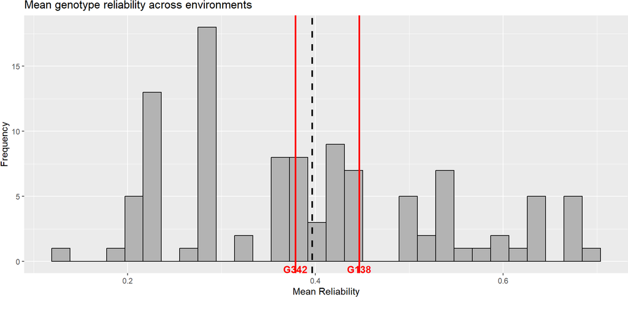

Figure 12: Average reability of the 107 genotypes evaluated in the multi environment trial network in Zambia

```r
  preds <- predict(mod5, classify = "env:gen", sed = TRUE, pworkspace = "8000mb")

  tabela_blups <- preds$pvals

  # Calcular a PEV (Prediction Error Variance)
  tabela_blups$PEV <- tabela_blups$std.error^2

  print(summary(mod5)$varcomp)
  varcomp <- summary(mod5)$varcomp

  sigma2_G_valores <- c(
    "E0103" = varcomp[4,1],
    "E0104" = varcomp[5,1],
    "E0105" = varcomp[6,1],
    "E0106" = varcomp[7,1],
    "E0107" = varcomp[8,1],
    "E0169" = varcomp[9,1],
    "E0170" = varcomp[10,1],
    "E0171" = varcomp[11,1],
    "E0172" = varcomp[12,1],
    "E0173" = varcomp[13,1],
    "E0174" = varcomp[14,1],
    "E0176" = varcomp[15,1],
    "E0225" = varcomp[16,1],
    "E0226" = varcomp[17,1],
    "E0227" = varcomp[18,1],
    "E0228" = varcomp[19,1],
    "E0229" = varcomp[20,1],
    "E0230" = varcomp[21,1],
    "E0252" = varcomp[22,1],
    "E0253" = varcomp[23,1],
    "E0254" = varcomp[24,1],
    "E0255" = varcomp[25,1],
    "E0278" = varcomp[26,1],
    "E0279" = varcomp[27,1],
    "E0282" = varcomp[28,1],
    "E0283" = varcomp[30,1],
    "E0284" = varcomp[31,1]
  )

  tabela_blups$sigma2_G <- sigma2_G_valores[tabela_blups$env]

  # Reliability = 1 - (PEV / Vgen)
  tabela_blups$Reliability <- 1 - (tabela_blups$PEV / tabela_blups$sigma2_G)

  # RESULTADO FINAL
  resultado_final <- tabela_blups[, c("env", "gen", "predicted.value", "std.error", "Reliability")]
  head(resultado_final)

  #mod5_reliability <- readRDS("reability3.rds")

  # Removendo valores negativos
  resultado_final <- resultado_final |> filter(Reliability > 0)

  summary(resultado_final)

  rel_gen <- resultado_final |>
    group_by(gen) |>
    summarise(
      mean_reliability = mean(Reliability, na.rm = TRUE),
      n_env = n(),
      .groups = "drop"
    )


  summary(rel_gen$mean_reliability)

  rel_env <- resultado_final |>
    group_by(env) |>
    summarise(
      mean_reliability = mean(Reliability, na.rm = TRUE),
      n_gen = n(),
      .groups = "drop"
    )


  # Genótipos de interesse
  gen_red <- c("G342", "G138")

  # Reliability média por genótipo
  rel_gen <- resultado_final |>
    group_by(gen) |>
    summarise(
      mean_reliability = mean(Reliability, na.rm = TRUE),
      n_env = n(),
      .groups = "drop"
    )

  # Valores dos genótipos destacados
  rel_red <- rel_gen |>
    filter(gen %in% gen_red)

  ggplot(rel_gen, aes(x = mean_reliability)) +
    geom_histogram(bins = 30, fill = "grey70", color = "black") +
    geom_vline(
      xintercept = mean(rel_gen$mean_reliability),
      linetype = "dashed",
      linewidth = 1
    ) +
    geom_vline(
      data = rel_red,
      aes(xintercept = mean_reliability),
      color = "red",
      linewidth = 1
    ) +
    geom_text(
      data = rel_red,
      aes(x = mean_reliability, y = 0, label = gen),
      color = "red",
      vjust = 1.5,
      fontface = "bold",
      size = 4
    ) +
    labs(
      title = "Mean genotype reliability across environments",
      x = "Mean Reliability",
      y = "Frequency"
    ) +
    coord_cartesian(clip = "off") +
    theme(plot.margin = margin(b = 20))
```

# Conclusion

The present study aimed to evaluate the phenotypic stability of 107 soybean genotypes across the Zambian trial network to identify superior materials for regional recommendation. The integration of classical stability methods (Eberhart & Russell regression and AMMI decomposition) with a predictive approach based on linear mixed models via REML/BLUP provided a robust and methodologically convergent framework for genotype selection.Across practically all analytical approaches, genotype G342 consistently emerged as the most stable and high-yielding material in the network. It combined a competitive mean yield above 2,500 kg/ha with low interaction scores in the AMMI biplots, minimal distance to the environmental maximum in the $P_i$ index, and high Safety-First values.

Furthermore, this study highlights the necessity of evolving beyond classical stability tools. While methods like Eberhart & Russell and AMMI provide valuable descriptive visualizations, their mathematical limitations and sensitivity to missing data in highly unbalanced networks are evident. The adoption of modern predictive frameworks, such as REML/BLUP mixed models, proved to be an important step. These models effectively handled the sparse nature of the dataset, shrank environmental noise, and provided the accurate breeding values required to compute reliable selection indices.